# ML2

Wytze Vlietstra

11/20/2017

# Introduction

A new feature set has been created, based on another reference set, and which does not transform the “counts” of the intermediate entities. The new files appear to be in line with our requested changes sent by email on 09-11-2017.

```r
# Create the positive set
count_pos = read.csv("count_pos.csv", stringsAsFactors = F)
diversity_pos = read.csv("diversity_pos.csv", stringsAsFactors = F)
pos = merge(count_pos, diversity_pos, by = intersect(colnames(count_pos), colnames(diversity_pos)))
pos$goldstandard = "VALID"

# Create the negative set
count_neg = read.csv("count_neg.csv", stringsAsFactors = F)
diversity_neg = read.csv("diversity_neg.csv", stringsAsFactors = F)
neg = merge(count_neg, diversity_neg, by = intersect(colnames(count_neg), colnames(diversity_neg)))
neg$goldstandard = "INVALID"
```

There appears to be a difference in the number of rows between the diversity and the count negative files. This difference becomes more pronounced when they are merged. Furthermore, the rows are not unique. We perform our further experiments with the unique instances of the negative file.

```
## [1] "The number of rows in the negative diversity file is 2164"
```

```
## [1] "The number of unique rows in the negative diversity file is 2114"
```

```
## [1] "The number of rows in the negative count file is 2165"
```

```
## [1] "The number of unique rows in the negative count file is 2163"
```

```
## [1] "The number of rows in the negative file is 2708"
```

```
## [1] "The number of unique rows in the complete negative set is 2576"
```

There appears to be a difference between the number of columns of the positive set and the negative set. The non-overlapping columns are printed below.

```r
print(paste("The number of columns for the positive set is", ncol(pos)))
```

```
## [1] "The number of columns for the positive set is 139"
```

```r
print(paste("The number of columns for the negative set is", ncol(neg)))
```

```
## [1] "The number of columns for the negative set is 137"
```

```r
print(paste("The differing columns are", paste(setdiff(colnames(pos), colnames(neg)), collapse = ", ")))
```

```
## [1] "The differing columns are Amphibian, Educational.Activity, Amino.Acid.Sequence"
```

```r
all = rbind.fill(pos, neg)
all[is.na(all)] = 0
# Some columns are empty, meaning their sum is 0. Others are not relevant as features. These are also removed
all$direct = as.logical(all$direct)
goldstandard = all$goldstandard
exclusion_columns = c("Drug", "Disease", "Drugbank.ID", "Disease.ID", "drug_ids", "disease_ids", "goldstandard")
feature_set = all[,-which(colnames(all) %in% exclusion_columns)]
feature_set = feature_set[,-which(colnames(feature_set) %in% names(which(colSums(feature_set) == 0)))]
```

# Feature correlations

To identify which features correlate with each other, we create a correlation matrix.

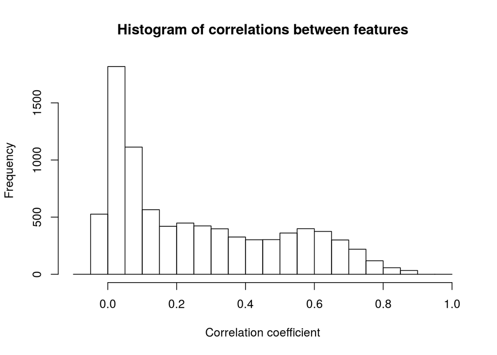

```r
# Create a correlation matrix
input_matrix = as.matrix(cor(feature_set))
feature_cors = arrange(melt(input_matrix), -abs(value))
feature_combos = feature_cors[!feature_cors$value > 0.9, ]

# Remove duplicate values from correlation matrix
feature_combos$A = NA
feature_combos$B = NA
feature_combos$Var1 = as.character(feature_combos$Var1)
feature_combos$Var2 = as.character(feature_combos$Var2)
for(i in 1:nrow(feature_combos)){
  feature_combos[i,c("A", "B")] = feature_combos[i, order(feature_combos[i, c("Var1", "Var2")])]
}
feature_combos = unique(feature_combos[,c("A", "B", "value")])
feature_combos = feature_combos[order(feature_combos$value, decreasing = T), ]
hist(feature_combos$value, main = "Histogram of correlations between features", xlab = "Correlation coefficient", xlim = c(-0.1,1), breaks = seq(-0.1,1, 0.05))
```

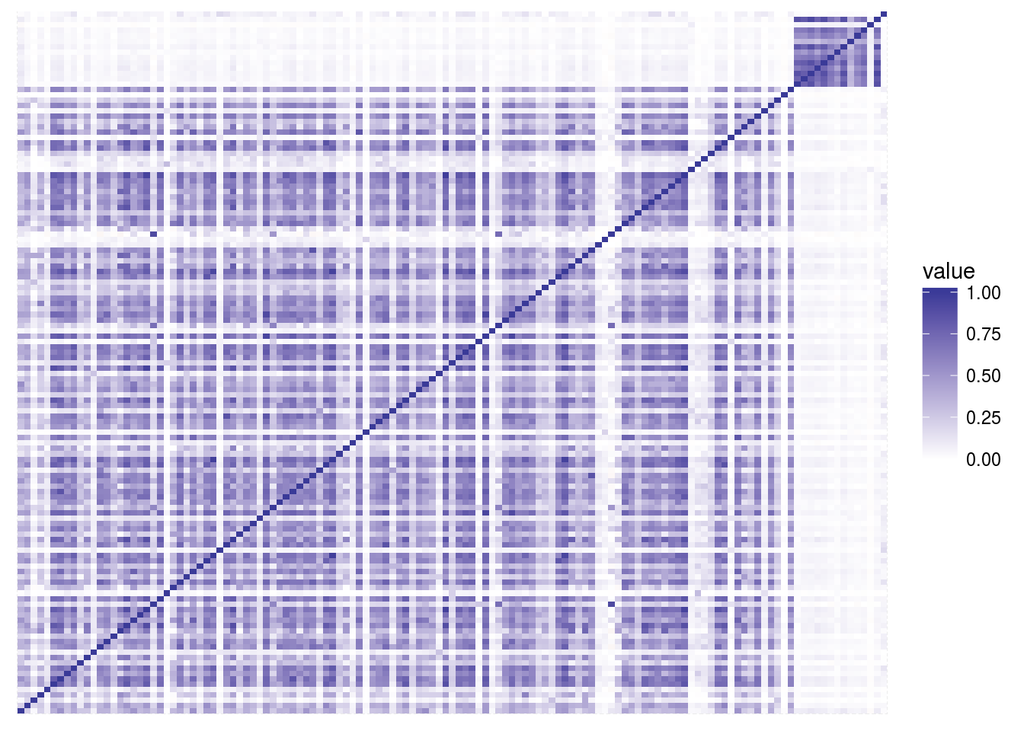

```r
colnames(feature_combos) = c("A", "B", "correlation")

qplot(x=Var1, y=Var2, data=feature_cors, fill=value, geom="tile") +
  scale_fill_gradient2(limits=c(min(feature_cors$value), 1)) +
theme(axis.text.x = element_blank(), axis.text.y = element_blank(),
      axis.ticks.x = element_blank(), axis.ticks.y = element_blank(),
      axis.title.x = element_blank(), axis.title.y = element_blank())
```

```r
kable(feature_combos[1:25,])
```

|  | A | B | correlation |
| --- | --- | --- | --- |
| 154 | Cell.Function | Enzyme | 0.8979770 |
| 156 | Biologically.Active.Substance | Chemical.Viewed.Structurally | 0.8947325 |
| 158 | Amino.Acid..Peptide..or.Protein | Receptor | 0.8943882 |
| 160 | Chemicals…Drugs | Physiology | 0.8921979 |
| 162 | Amino.Acid..Peptide..or.Protein | Cell.Function | 0.8878734 |
| 164 | Chemical.Viewed.Structurally | Element..Ion..or.Isotope | 0.8877083 |
| 166 | Cell.Function | Genetic.Function | 0.8828979 |
| 168 | Amino.Acid..Peptide..or.Protein | Chemical.Viewed.Structurally | 0.8816304 |
| 170 | Amino.Acid..Peptide..or.Protein | Immunologic.Factor | 0.8803518 |
| 172 | Chemicals…Drugs | Procedures | 0.8793754 |
| 174 | Biologically.Active.Substance | Cell.Function | 0.8763050 |
| 176 | Disorders | Procedures | 0.8757871 |
| 178 | Enzyme | Genetic.Function | 0.8754765 |
| 180 | Disorders | Physiology | 0.8746982 |
| 182 | Chemical.Viewed.Structurally | Finding | 0.8708320 |
| 184 | Chemicals…Drugs | Living.Beings | 0.8698308 |
| 186 | Biologically.Active.Substance | Receptor | 0.8656293 |
| 188 | Disorders | Living.Beings | 0.8652827 |
| 190 | Organ.or.Tissue.Function | Physiologic.Function | 0.8646756 |
| 192 | Biologically.Active.Substance | Element..Ion..or.Isotope | 0.8646442 |
| 194 | Biologically.Active.Substance | Genetic.Function | 0.8641475 |
| 196 | Enzyme | Receptor | 0.8628028 |
| 198 | Amino.Acid..Peptide..or.Protein | Pharmacologic.Substance | 0.8609995 |
| 200 | Amino.Acid..Peptide..or.Protein | Laboratory.Procedure | 0.8607031 |
| 202 | Cell.Component | Tissue | 0.8602925 |

# Descriptive statistics for all columns

```r
descriptive_statistics = data.frame(
mean_valid = apply(feature_set[which(goldstandard == "VALID"),], 2, mean),
sd_valid = apply(feature_set[which(goldstandard == "VALID"),], 2, sd),
max_valid = apply(feature_set[which(goldstandard == "VALID"),], 2, max),

mean_invalid = apply(feature_set[which(goldstandard == "INVALID"),], 2, mean),
sd_invalid = apply(feature_set[which(goldstandard == "INVALID"),], 2, sd),
max_invalid = apply(feature_set[which(goldstandard == "INVALID"),], 2, max)
)
descriptive_statistics$difference = descriptive_statistics$mean_valid - descriptive_statistics$mean_invalid
descriptive_statistics = descriptive_statistics[order(row.names(descriptive_statistics)),]
kable(descriptive_statistics)
```

|  | mean_valid | sd_valid | max_valid | mean_invalid | sd_invalid | max_invalid | difference |
| --- | --- | --- | --- | --- | --- | --- | --- |
| Acquired.Abnormality | 0.3385785 | 1.0515133 | 16 | 0.4316770 | 1.1873075 | 18 | -0.0930985 |
| Activities…Behaviors | 0.3810113 | 0.7202908 | 4 | 0.4013975 | 0.7740839 | 4 | -0.0203862 |
| Activity | 0.2510608 | 0.6779975 | 8 | 0.2430124 | 0.6699875 | 5 | 0.0080484 |
| Age.Group | 3.0823904 | 3.4321414 | 27 | 2.8866460 | 3.5631829 | 20 | 0.1957444 |
| Amino.Acid..Peptide..or.Protein | 18.5305870 | 46.6253968 | 623 | 41.1083075 | 73.1059101 | 634 | -22.5777205 |
| Amino.Acid.Sequence | 0.0003536 | 0.0188028 | 1 | 0.0000000 | 0.0000000 | 0 | 0.0003536 |
| Amphibian | 0.0001768 | 0.0132967 | 1 | 0.0000000 | 0.0000000 | 0 | 0.0001768 |
| Anatomical.Abnormality | 0.3224894 | 0.9412240 | 15 | 0.4813665 | 1.1499440 | 19 | -0.1588771 |
| Anatomical.Structure | 0.0033593 | 0.0636860 | 2 | 0.0093168 | 0.1000512 | 2 | -0.0059575 |
| Anatomy | 2.2324965 | 2.0748704 | 9 | 3.0458075 | 2.0911830 | 8 | -0.8133110 |
| Animal | 0.8719943 | 1.3798681 | 9 | 0.9860248 | 1.5360391 | 11 | -0.1140305 |
| Antibiotic | 5.1755658 | 12.8020270 | 270 | 3.4103261 | 8.2178892 | 126 | 1.7652397 |
| Archaeon | 0.0005304 | 0.0230266 | 1 | 0.0007764 | 0.0278585 | 1 | -0.0002460 |
| Bacterium | 2.0740806 | 7.2532314 | 100 | 0.7138975 | 6.5174938 | 138 | 1.3601831 |
| Biologically.Active.Substance | 9.6828147 | 24.4408341 | 284 | 21.0287267 | 38.6633460 | 342 | -11.3459120 |
| Biologic.Function | 0.1858204 | 0.5880783 | 6 | 0.3618012 | 0.8528197 | 7 | -0.1759809 |
| Biomedical.Occupation.or.Discipline | 0.0003536 | 0.0188028 | 1 | 0.0007764 | 0.0278585 | 1 | -0.0004228 |
| Biomedical.or.Dental.Material | 0.3115276 | 0.9747555 | 11 | 0.4130435 | 1.0894947 | 18 | -0.1015159 |
| Bird | 0.0045969 | 0.0702156 | 2 | 0.0108696 | 0.1073885 | 2 | -0.0062727 |
| Body.Location.or.Region | 0.0541018 | 0.2977798 | 6 | 0.0485248 | 0.3020541 | 4 | 0.0055770 |
| Body.Part..Organ..or.Organ.Component | 5.0949434 | 11.5849686 | 210 | 8.7045807 | 14.6864469 | 183 | -3.6096373 |
| Body.Space.or.Junction | 0.0017680 | 0.0420145 | 1 | 0.0011646 | 0.0341129 | 1 | 0.0006034 |
| Body.Substance | 0.6449788 | 1.5342317 | 23 | 0.7034161 | 1.6397265 | 33 | -0.0584374 |
| Body.System | 0.0555163 | 0.2733581 | 2 | 0.0197981 | 0.1648657 | 2 | 0.0357181 |
| Carbohydrate | 2.0470297 | 4.9181360 | 91 | 2.9697205 | 6.4161701 | 59 | -0.9226908 |
| Cell | 2.3445898 | 6.0566643 | 72 | 8.1812888 | 20.0763817 | 435 | -5.8366990 |
| Cell.Component | 1.1138614 | 2.4284882 | 38 | 2.2907609 | 3.7161009 | 29 | -1.1768995 |
| Cell.Function | 1.6352546 | 4.5673761 | 51 | 5.0784161 | 8.5684941 | 55 | -3.4431616 |
| Cell.or.Molecular.Dysfunction | 0.5484441 | 1.4862010 | 17 | 1.7686335 | 3.2211742 | 20 | -1.2201894 |
| Chemical | 0.1034300 | 0.3918925 | 5 | 0.2061335 | 0.5452507 | 6 | -0.1027036 |

[output cut: 101 more lines]

For some of the columns there are big differences.

# Machine learning

Same as previously, we apply the machine learning algorithm to the dataset. First we apply the random forest algorithm

```r
rf_model = train(x = feature_set, y = goldstandard, method = "rf",
              trControl=trainControl(method="cv",number=10, classProbs = TRUE,
              savePredictions = TRUE, summaryFunction = twoClassSummary),
              prox=TRUE, allowParallel=TRUE, metric = "ROC")
kable(rf_model$results[rf_model$results$mtry == rf_model$bestTune$mtry, c("ROC", "Sens", "Spec")])
```

[output not shown]

We analyse the distributions of the most predictive features.

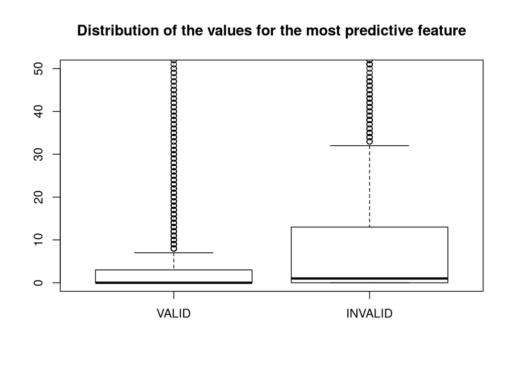

```r
importances = data.frame(Feature = rownames(varImp(rf_model)$importance), score = varImp(rf_model)$importance$Overall)
importances = importances[order(importances$score, decreasing = T), ]
boxplot(all[all$goldstandard == "VALID", importances$Feature[1]], all[all$goldstandard == "INVALID", importances$Feature[1]],
        main = "Distribution of the values for the most predictive feature", ylim = c(0,50), names = c("VALID", "INVALID"))
```

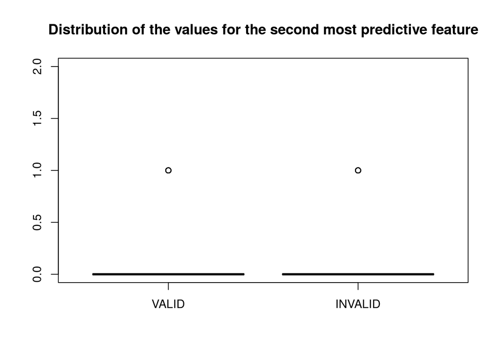

```r
boxplot(all[all$goldstandard == "VALID", importances$Feature[2]], all[all$goldstandard == "INVALID", importances$Feature[2]],
        main = "Distribution of the values for the second most predictive feature", ylim = c(0,2), names = c("VALID", "INVALID"))
```

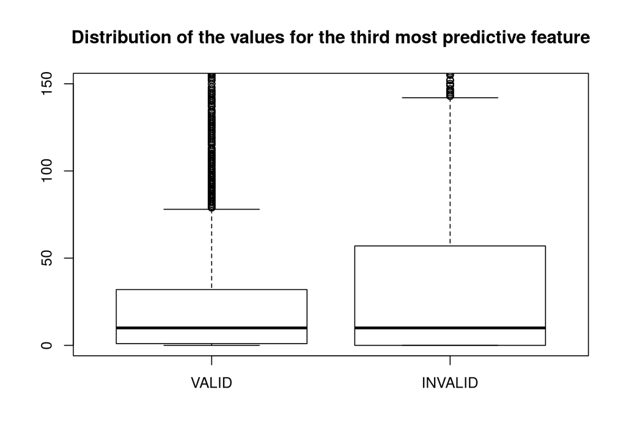

```r
boxplot(all[all$goldstandard == "VALID", importances$Feature[3]], all[all$goldstandard == "INVALID", importances$Feature[3]],
        main = "Distribution of the values for the third most predictive feature", ylim = c(0,150), names = c("VALID", "INVALID"))
```

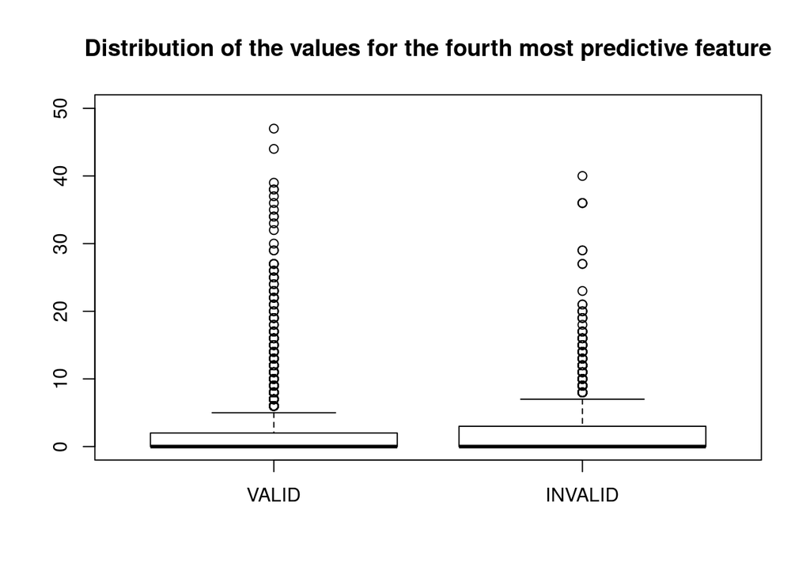

```r
boxplot(all[all$goldstandard == "VALID", importances$Feature[4]], all[all$goldstandard == "INVALID", importances$Feature[4]],
        main = "Distribution of the values for the fourth most predictive feature", ylim = c(0,50), names = c("VALID", "INVALID"))
```

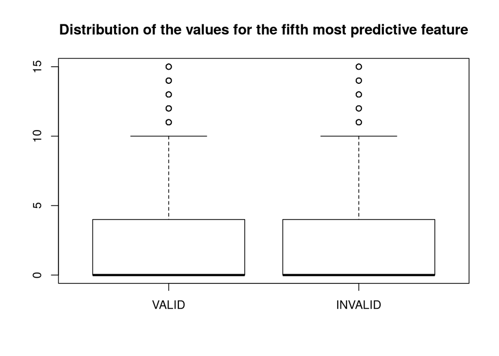

```r
boxplot(all[all$goldstandard == "VALID", importances$Feature[5]], all[all$goldstandard == "INVALID", importances$Feature[5]],
        main = "Distribution of the values for the fifth most predictive feature", ylim = c(0,15), names = c("VALID", "INVALID"))
```

Unlike the previous dataset, it the differences between the positive set and the negative set appear to be much smaller this time.

# Equally sized classification

Because there is a ~ 2:1 class imbalance between the two classes, we examine how performance is affected when there is an equal distribution between the two classes.

```r
createBalancedSet = function(df, n, pos_class = "VALID"){
  balanced = rbind(df[sample(row.names(df[df$goldstandard == pos_class, ]), n),],
                   df[sample(row.names(df[!df$goldstandard == pos_class, ]), n),])
  return(balanced)}

freqs = table(goldstandard)

equal_set = createBalancedSet(all, min(freqs))
equal_standard = equal_set$goldstandard
equal_set = equal_set[,-which(colnames(equal_set) %in% exclusion_columns)]

equal_rf_model = train(x = equal_set, y = equal_standard, method = "rf",
              trControl=trainControl(method="cv",number=10, classProbs = TRUE,
              savePredictions = TRUE, summaryFunction = twoClassSummary),
              prox=TRUE, allowParallel=TRUE, metric = "ROC")

kable(equal_rf_model$results[equal_rf_model$results$mtry == equal_rf_model$bestTune$mtry, c("ROC", "Sens", "Spec")])
```

|  | ROC | Sens | Spec |
| --- | --- | --- | --- |
| 2 | 0.9439602 | 0.856743 | 0.8858776 |

# Label scrambling check

The labels are scrambled by random ones, again with an equal distribution to see whether performance changes

```r
scrambled_standard = sample(c("VALID", "INVALID"), 2*min(freqs), replace = T)

scrambled_rf_model = train(x = equal_set, y = scrambled_standard, method = "rf",
              trControl=trainControl(method="cv",number=10, classProbs = TRUE,
              savePredictions = TRUE, summaryFunction = twoClassSummary),
              prox=TRUE, allowParallel=TRUE, metric = "ROC")
kable(scrambled_rf_model$results[scrambled_rf_model$results$mtry == scrambled_rf_model$bestTune$mtry, c("ROC", "Sens", "Spec")])
```

| ROC | Sens | Spec |
| --- | --- | --- |
| 0.4955003 | 0.3237586 | 0.6805706 |

# Internal classification check

Another check is performed by quantifying whether the classifier is able to group the negative set itself, or the positive.

```r
neg_scrambled_standard = sample(c("VALID", "INVALID"), nrow(neg), replace = T)

neg_input = neg[,-which(colnames(neg) %in% exclusion_columns)]
neg_input[is.na(neg_input)] = 0
neg_input$direct = as.logical(neg_input$direct)

neg_rf_model = train(x = neg_input, y = neg_scrambled_standard, method = "rf",
              trControl=trainControl(method="cv",number=10, classProbs = TRUE,
              savePredictions = TRUE, summaryFunction = twoClassSummary),
              prox=TRUE, allowParallel=TRUE, metric = "ROC")

kable(neg_rf_model$results[neg_rf_model$results$mtry == neg_rf_model$bestTune$mtry, c("ROC", "Sens", "Spec")])
```

| ROC | Sens | Spec |
| --- | --- | --- |
| 0.5067483 | 0.3269685 | 0.690161 |

```r
pos_scrambled_standard = sample(c("VALID", "INVALID"), nrow(pos), replace = T)

pos_input = pos[,-which(colnames(pos) %in% exclusion_columns)]
pos_input[is.na(pos_input)] = 0
pos_input$direct = as.logical(pos_input$direct)

pos_rf_model = train(x = pos_input, y = pos_scrambled_standard, method = "rf",
              trControl=trainControl(method="cv",number=10, classProbs = TRUE,
              savePredictions = TRUE, summaryFunction = twoClassSummary),
              prox=TRUE, allowParallel=TRUE, metric = "ROC")

kable(neg_rf_model$results[neg_rf_model$results$mtry == neg_rf_model$bestTune$mtry, c("ROC", "Sens", "Spec")])
```

| ROC | Sens | Spec |
| --- | --- | --- |
| 0.5067483 | 0.3269685 | 0.690161 |

# Linear regression

Finally, we perform a linear regression as a control.

| ROC | Sens | Spec |
| --- | --- | --- |
| 0.8609657 | 0.5737837 | 0.9078874 |

As can be seen, the linear regression already performs very well, although not as good as the random forest.

# TODOS

- Quantify the performance when only a single, highly predictive feature is taken.
- Remove the most predictive features, and run the analysis again
- Compare the most predictive features to each other
- Apply Guney’s code